# Dutch Dashboard analyses

Dan Weinberger

1/13/2021

```
## Wrote object to Data//case_data/2021_02_15_16_04.rds
```

## Daily reported cases.

Observed (gray) or smoothed trend. The smoothed trend is estimated using seasonal trend decomposition with loess smoothing (STL). This removes the day-of-week effects and random noise.

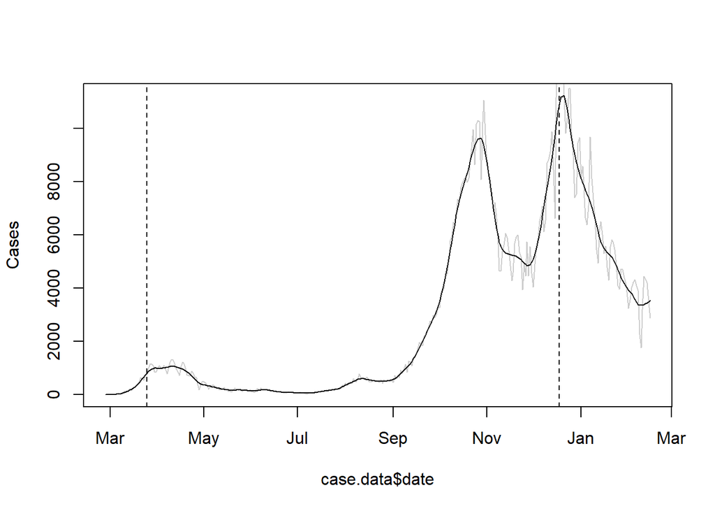

Crude 7 day Rate ratio (gray) or simple rolling average of rate ratio (black), or ratio calculated from smoothed trend (red)

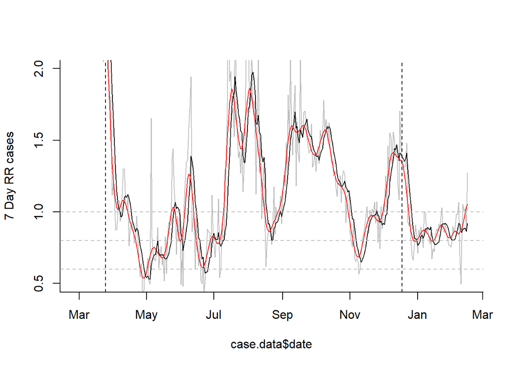

Simple extrapolation of the current trend

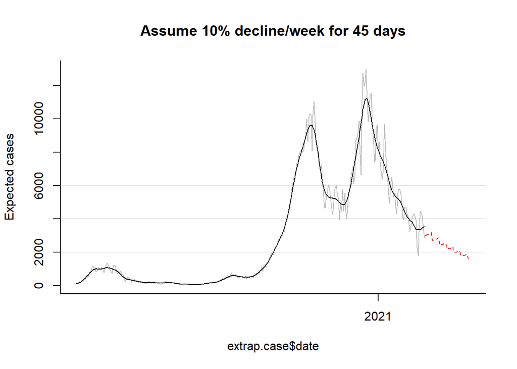

## Hospitalization data

```
## Wrote object to Data//nice_data/2021_02_15_16_05.rds
```

Observed admissions by day, and smoothed admissions. Smoothing is performed using the STL function to subtract the day-of-week effect and random noise.

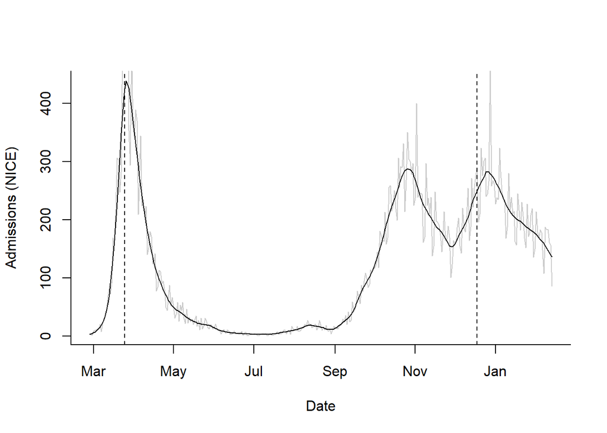

Crude 7 day Rate ratio (gray) or simple rolling average of rate ratio (black), or ratio calculated from smoothed trend (red)

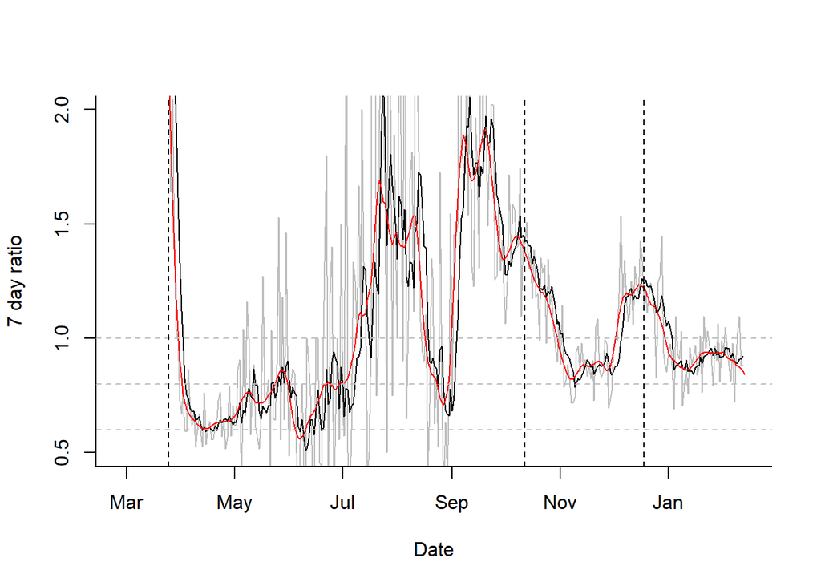

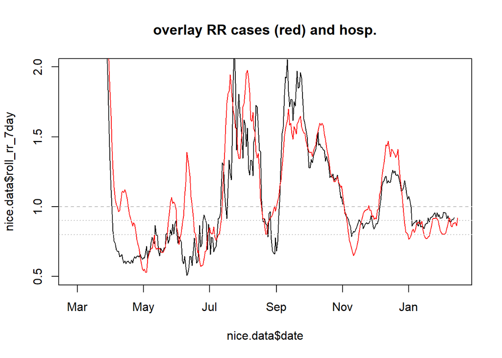

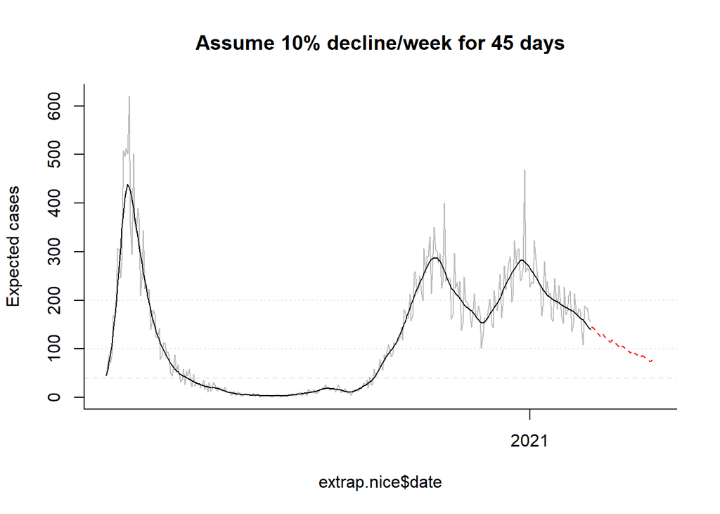